# Intro to R Markdown

Emily Bellis

5/4/2020

## What is Markdown?

- Markdown is a plain text formatting syntax for authoring HTML, PDF, and MS Word documents.
- Provides a standard way of formatting text, like

  *italics*  
  **bold**  
  `code`
  - lists, and
    - [links](https://rmarkdown.rstudio.com)
    - Latex equations like $E = mc^{2}$ and $\sum_{i=1}^{n}\beta_i$
    - and bibliographies

## What is Markdown?

- BUT original version did not include syntax for tables, footnotes, math expressions, or citations
- Enter [pandoc](https://pandoc.org), a ‘swiss-army knife’ for converting between markup formats
- *A markup language is a system for annotating a document in a way that is syntactically distinguishable from the text; markup language is not shown when the document is processed for display*

## What is R Markdown?

- “R markdown” document format was first introduced in 2012 as part of **knitr** package, enabling users to embed code chunks in Markdown documents.
- The **rmarkdown** package, first created in 2014, provides an ‘ecosystem’ for authoring documents.

[figure not shown]

rmarkdown, knitr, and pandoc

## Slide with R Output

```r
library(dplyr)
library(knitr)
kable(starwars[1:5,c(1:3,5,8:10)])
```

| name | height | mass | skin_color | gender | homeworld | species |
| --- | --- | --- | --- | --- | --- | --- |
| Luke Skywalker | 172 | 77 | fair | male | Tatooine | Human |
| C-3PO | 167 | 75 | gold | NA | Tatooine | Droid |
| R2-D2 | 96 | 32 | white, blue | NA | Naboo | Droid |
| Darth Vader | 202 | 136 | white | male | Tatooine | Human |
| Leia Organa | 150 | 49 | light | female | Alderaan | Human |

## Slide with Plot

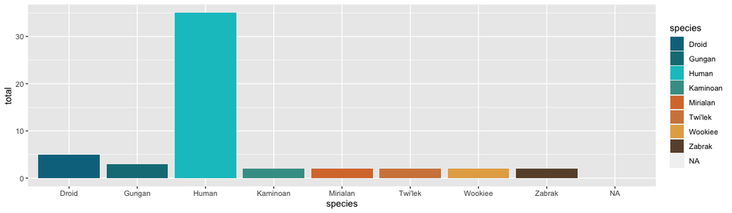

Star Wars Character Biodiversity

```r
library(ggplot2)
library(beyonce)
tmp <- starwars %>% group_by(species)%>% summarise(total= n()) %>% filter(total > 1)
ggplot(tmp, aes(x=species, y=total, fill=species)) + geom_bar(stat = "identity") + scale_fill_manual(values = beyonce_palette(75, n=9,type="discrete"))
```

## What is R Markdown?

R Markdown also supports other languages, such as Python, Julia, C++, and SQL thanks to the **knitr** package, which provides a large number of language engines.

Language engines are essentially functions registered in the object `knitr::knit_engine`.

```r
names(knitr::knit_engines$get())
```

```
##  [1] "awk"       "bash"      "coffee"    "gawk"      "groovy"
##  [6] "haskell"   "lein"      "mysql"     "node"      "octave"
## [11] "perl"      "psql"      "Rscript"   "ruby"      "sas"
## [16] "scala"     "sed"       "sh"        "stata"     "zsh"
## [21] "highlight" "Rcpp"      "tikz"      "dot"       "c"
## [26] "fortran"   "fortran95" "asy"       "cat"       "asis"
## [31] "stan"      "block"     "block2"    "js"        "css"
## [36] "sql"       "go"        "python"    "julia"     "sass"
## [41] "scss"
```

## Rendering a .Rmd file

**R Studio:**  
* Click the *Knit* button to generate document that includes both content and output of any embedded R code chunks within the document

**R Console:**

`rmarkdown::render('/path/to/file/Intro.Rmd')`

**CLI:**

`Rscript -e "rmarkdown::render('./Intro.Rmd')"`

## Incorporating in your academic life

- Lab Notebooks
- CV
- Data analysis reports for collaborators
- Write manuscripts
- Slides
- Websites
- Online textbooks
- Shiny apps
- Integrate with GitHub

## Resources for R Markdown

- [R Markdown: The Definitive Guide](https://bookdown.org/yihui/rmarkdown/) by Yihui Xie, J. J. Allaire, & Garrett Grolemund
- [Bookdown](https://bookdown.org/yihui/bookdown/) by Yihue Xie
- Some tutorials for ‘revealjs’ [here](https://garrettgman.github.io/rmarkdown/revealjs_presentation_format.html) and [here](http://www.jenniferbradham.org/post/reveal_js_markdown/)
- General tutorials and gallery from [RStudio](http://rmarkdown.rstudio.com)
- [Cheatsheet](https://rmarkdown.rstudio.com/lesson-15.html), also from RStudio interface Help > Cheatsheets

## Some Additional Notes

-Sensitive to spacing -Line with one trailing space -Line with two spaces  
-Another line

- Commenting with SHIFT+COMMAND+C (on a mac)
2. Ordered lists are kind of weird
3. Because the number you type doesn’t matter  
   8. But you can try using a non-breaking space.